# PSY4210: Data Visualization

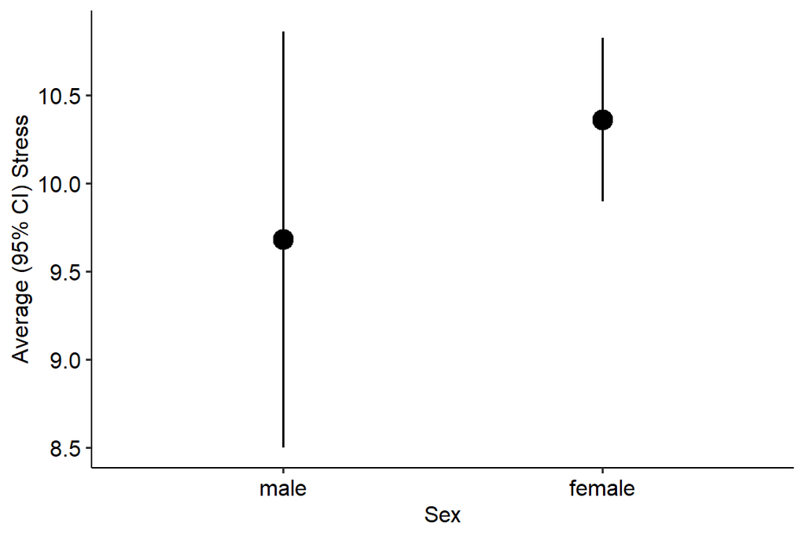

Mean and 95 percent confidence intervals

```r
ggplot(db[!is.na(sex)], aes(sex, Stress)) +
  stat_summary(fun.data = mean_cl_normal, size = 1) +
  theme_pubr() +
  ylab("Average (95% CI) Stress") +
  xlab("Sex")
```

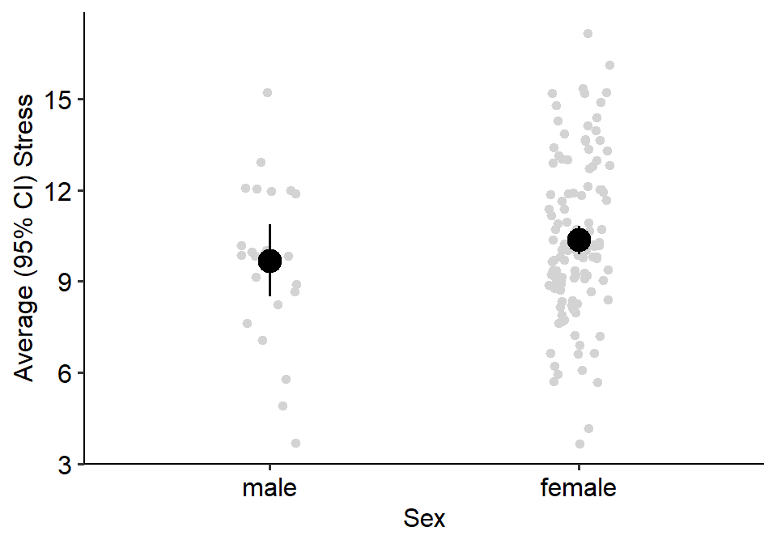

Mean and 95 percent confidence interval with data

```r
ggplot(db[!is.na(sex)], aes(sex, Stress)) +
  geom_jitter(colour = "lightgrey", width = .1) +
  stat_summary(fun.data = mean_cl_normal, size = 1) +
  theme_pubr() +
  ylab("Average (95% CI) Stress") +
  xlab("Sex")
```

```r
## view the labels for one of the ULS items
attr(db$ULS1, "labels")
```

```
    Never    Rarely Sometimes     Often
        1         2         3         4
```

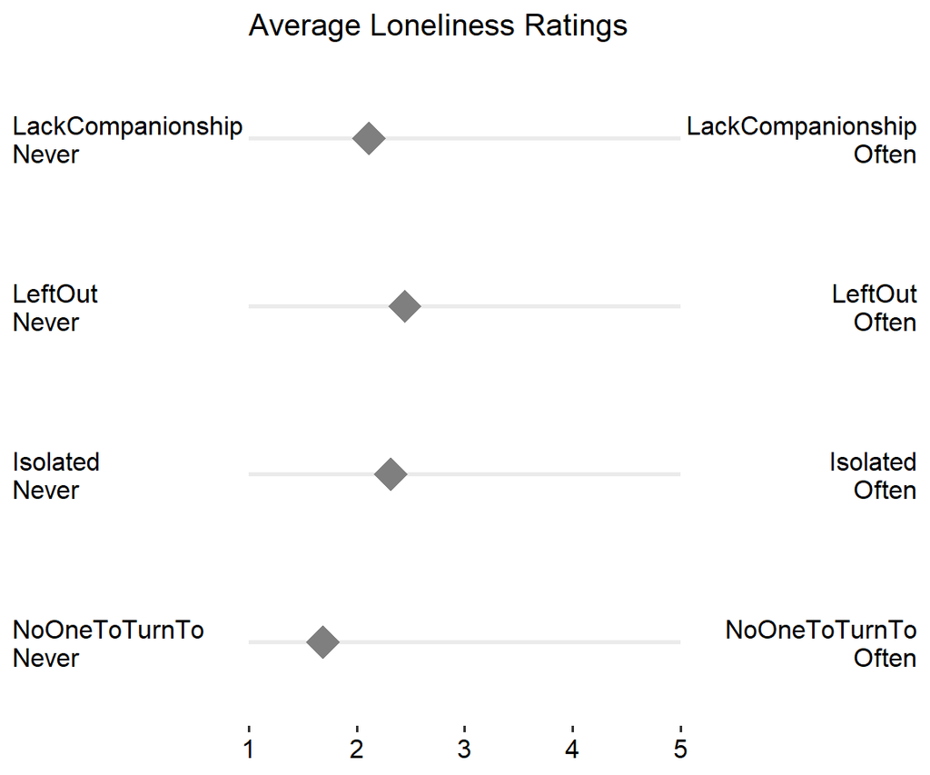

Likert plot of means showing anchors

```r
## make a summarised dataset with the means and labels
sumdat <- melt(db[, .(ID,
            LackCompanionship = ULS1, LeftOut = ULS4,
            Isolated = ULS5, NoOneToTurnTo = ULS2)], id.vars = "ID")[,
  .(Mean = mean(value, na.rm = TRUE)), by = variable]
sumdat[, Never := paste0(variable, "\nNever")]
sumdat[, Often := paste0(variable, "\nOften")]

## make a likert plot
gglikert("Mean", "variable", "Never", "Often", data = sumdat,
         xlim = c(1, 5),
         title = "Average Loneliness Ratings")
```

# 8 Summary Table for Data visualisation

Here is a little summary of some of the functions used so far. You might also enjoy this “cheatsheet” for `ggplot2`: https://github.com/rstudio/cheatsheets/raw/master/data-visualization-2.1.pdf

| Function | What it does |
| --- | --- |
| `ggplot()` | Sets the dataset and which variables map to which aesthetics for a plot |
| `geom_boxplot()` | Adds geometric object for boxplots |
| `geom_density()` | Adds a geometric object for density lines, a way to view a distribution |
| `geom_histogram()` | Adds a geometric object for a histogram, a way to view a distribution |
| `geom_jitter()` | Adds a points with some automatic random noise, helpful when one axis is discrete |
| `stat_summary()` | Used to automatically calculated some summary statistics on data and plot, usually means with standard errors or confidence intervals |
| `gglikert()` | Create a likert type plot showing means typically with the scale anchors |
| `plot(testDistribution())` | Used to check whether a variable follows a specific, assumed distribution, typically a normal distribution |
| `ylab()` | Adds a label for the y axis |
| `xlab()` | Adds a label for the x axis |

# 9 More advanced data visualisation - Categorical and Continuous variables

```r
## compute the personality variables if you haven't already done so
db [, BFI_N1 := 6 - BFI_N1r]
db[, neuroticism:= rowMeans(.SD, na.rm = TRUE),
.SDcols = c("BFI_N1", "BFI_N2")]

db [, BFI_E1 := 6 - BFI_E1r]
db[, extraversion := rowMeans(.SD, na.rm = TRUE),
   .SDcols = c("BFI_E1", "BFI_E2")]

db [, BFI_O1 := 6 - BFI_O1r]
db[, openness := rowMeans(.SD, na.rm = TRUE),
   .SDcols = c("BFI_O1", "BFI_O2")]

db [, BFI_C1 := 6 - BFI_C1r]
db[, conscientiousness := rowMeans(.SD, na.rm = TRUE),
   .SDcols = c("BFI_C1", "BFI_C2")]

db [, BFI_A2 := 6 - BFI_A2r]
db[, agreeableness := rowMeans(.SD, na.rm = TRUE),
   .SDcols = c("BFI_A1", "BFI_A2")]

## create some binary variables (based on the median - will see another way to create based on median later)
db[, StressHigh := factor(Stress >= 10, levels = c(TRUE, FALSE), labels = c("High Stress","Low Stress"))]
db[, SelfesteemHigh := factor(SE >= 3.8, levels = c(TRUE, FALSE), labels = c("High SE", "Low SE"))]
```

# 10 All Categorical Variables

If we are working with all categorical variables, a common way to present them is to make one variable “continuous” by calculating the percentages. For example, suppose that in our baseline data collection exercise data, we wanted to graph the association between categorical self-esteem and sex

```r
egltable("SelfesteemHigh", g = "sex", data = db)
```

```
                  male N (%) female N (%)
           <char>     <char>       <char>
1: SelfesteemHigh
2:        High SE  8 (36.4%)   51 (42.9%)
3:         Low SE 14 (63.6%)   68 (57.1%)
                                              Test
                                            <char>
1: Chi-square = 0.32, df = 1, p = .571, Phi = 0.05
2:
3:
```

## 10.1 Bar Plot

We can get a frequency table easily enough (as shown in the earlier code), but what if we wanted to graph it?

We could graph the frequencies, such as with a bar plot.

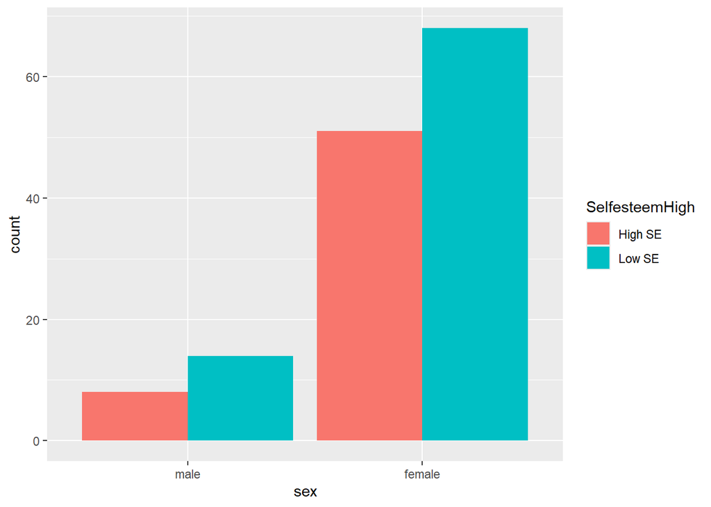

```r
p.bar <- ggplot(db[!is.na(sex)], aes(sex, fill = SelfesteemHigh)) +
  geom_bar(position = "dodge")

print(p.bar)
```

Beyond the data to ink ratio issues, if we were presenting this or putting it into a paper, we would want to label it more cleanly. Here we remove the x-axis title, since saying male and female makes it clear enough we don’t need to say “sex” is the variable name anymore. We could relabel the y axis (although count is fairly clear, I wanted to show how to do it). The theme cleans up and makes the font a bit bigger.

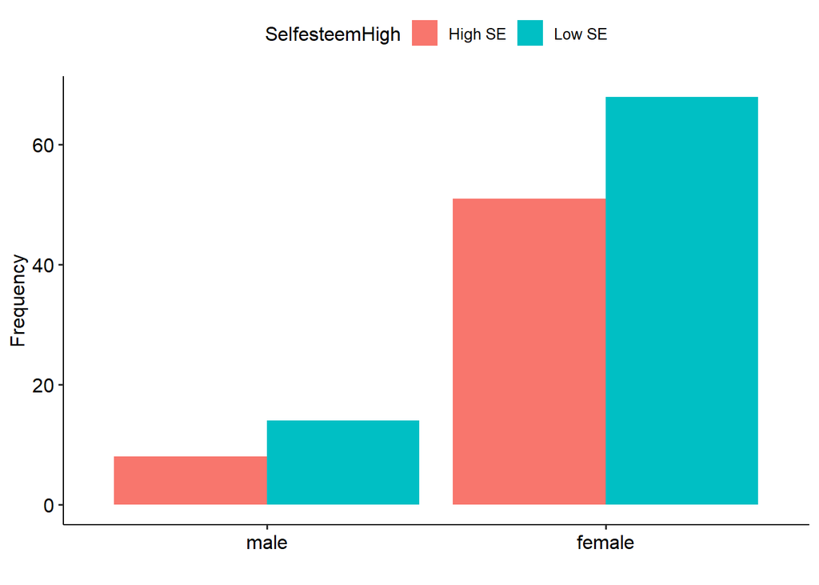

```r
p.bar2 <- p.bar  +
  xlab("") +
  ylab("Frequency") +
  theme_pubr()

print(p.bar2)
```

**Note**

You can find more about customizing guides here: https://ggplot2.tidyverse.org/reference/guide_legend.html

We can change `SelfesteemHigh` by using `scale_fill_manual()` which lets us name the title of the legend and to specify the colours, by name or hexademical codes, for each group to make it black and white. We use the `coord_cartesian()` function to stop the axis expansion so that it begins exactly at zero. Finally, we get a title, with math symbols by using the `ggtitle()` function listing the chi-square p-value from `egltable()` analysis earlier.

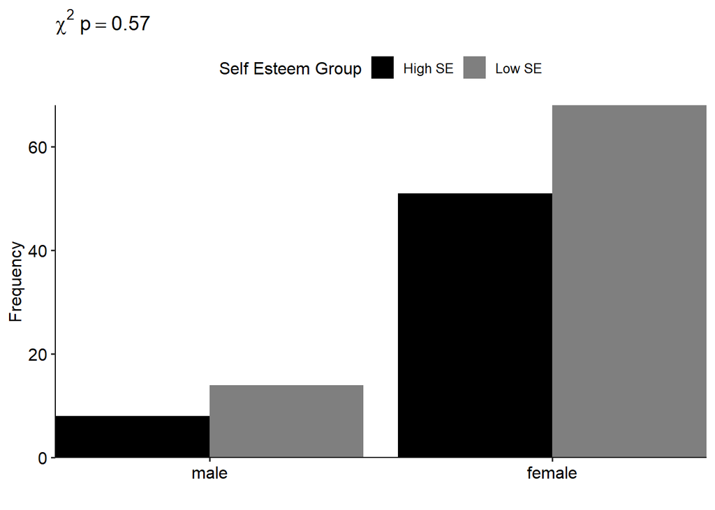

```r
p.bar3 <- p.bar2 +
  scale_fill_manual(
    "Self Esteem Group",
    values = c(
      "High SE" = "black",
      "Low SE" = "grey50")) +
  coord_cartesian(expand=FALSE) +
  ggtitle(expression(chi^2~p==.57))

print(p.bar3)
```

## 10.2 Percentage Plot

A simple way would be to calculate the percentage of `sex = "female"` in each self esteem category and plot that. We would create a new dataset with percentages calculated along with confidence intervals using the following code. We calculate the average number of `sex == "female"` which is the proportion, and then use the `prop.test()` function which takes the count in one group and the total count and can calculate confidence intervals to get 95% confidence intervals for the proportions.

```r
propdata <- db[!is.na(SelfesteemHigh), .(
  Percent = mean(sex == "female", na.rm = TRUE),
  LL = prop.test(
    x = sum(sex == "female", na.rm = TRUE),
    n = sum(!is.na(sex)), correct = FALSE)$conf.int[1],
  UL = prop.test(
    x = sum(sex == "female", na.rm = TRUE),
    n = sum(!is.na(sex)), correct = FALSE)$conf.int[2]),
  by = SelfesteemHigh]

print(propdata)
```

```
   SelfesteemHigh Percent    LL    UL
           <fctr>   <num> <num> <num>
1:         Low SE   0.829 0.734 0.895
2:        High SE   0.864 0.755 0.930
```

Now we can plot the results. All we need for a basic plot is the `ggplot()` and `geom_pointrange()` but the rest helps polish up the figure for presentation.

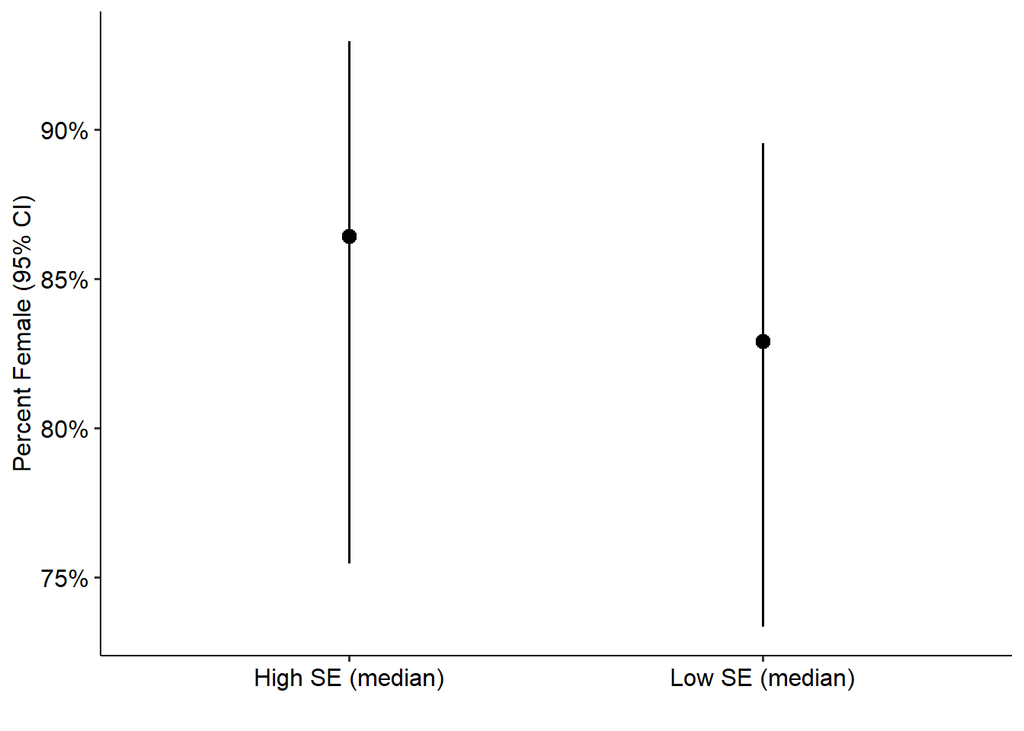

```r
p.prop1 <- ggplot(propdata, aes(SelfesteemHigh, y = Percent, ymin = LL, ymax = UL)) +
  geom_pointrange() +
  scale_y_continuous(labels = percent) +
  scale_x_discrete(
    breaks = c("High SE", "Low SE"),
    labels = c("High SE (median)", "Low SE (median)")) +
  xlab("") + ylab("Percent Female (95% CI)") +
 theme_pubr()

print(p.prop1)
```

The same basic strategy can work for many variables at scale fairly easily. For example, suppose that the personality dimensions were all categorical. We first create these categorical variables, noting that this is solely for the sake of demonstration. In general it is not a good idea to convert continuous variables to categorical ones.

```r
db[, O := as.integer(openness > median(openness, na.rm=TRUE))]
db[, C := as.integer(conscientiousness > median(conscientiousness, na.rm=TRUE))]
db[, E := as.integer(extraversion > median(extraversion, na.rm=TRUE))]
db[, A := as.integer(agreeableness > median(agreeableness, na.rm=TRUE))]
db[, N := as.integer(neuroticism > median(neuroticism, na.rm=TRUE))]

# Recall the content on reshaping from wide to long format from Lecture 2 (WorkData.rmd)
dblong <- reshape(
  db[!is.na(SelfesteemHigh), .(ID, SelfesteemHigh, O, C, E, A, N)],
  varying = list(Score = c("O", "C", "E", "A", "N")),
  v.names = "Score",
  timevar = "Personality",
  times = c("O", "C", "E", "A", "N"),
  idvar = "ID",
  direction = "long")

propdata2 <- dblong[, .(
  Percent = mean(Score == 1, na.rm = TRUE),
  LL = prop.test(
    x = sum(Score == 1, na.rm = TRUE),
    n = sum(!is.na(Score)), correct = FALSE)$conf.int[1],
  UL = prop.test(
    x = sum(Score == 1, na.rm = TRUE),
    n = sum(!is.na(Score)), correct = FALSE)$conf.int[2]),
  by = .(SelfesteemHigh, Personality)]

propdata2[, Personality := factor(Personality,
   levels = c("O", "C", "E", "A", "N"))]

print(propdata2)
```

```
    SelfesteemHigh Personality Percent    LL    UL
            <fctr>      <fctr>   <num> <num> <num>
 1:         Low SE           O   0.427 0.325 0.535
 2:        High SE           O   0.390 0.276 0.517
 3:         Low SE           C   0.232 0.154 0.334
 4:        High SE           C   0.458 0.337 0.583
 5:         Low SE           E   0.280 0.195 0.386
 6:        High SE           E   0.542 0.417 0.663
 7:         Low SE           A   0.378 0.281 0.486
 8:        High SE           A   0.593 0.466 0.709
 9:         Low SE           N   0.500 0.394 0.606
10:        High SE           N   0.441 0.322 0.567
```

Now we can plot the results. All we need for a basic plot is the `ggplot()`, `geom_pointrange()`, and `facet_grid()` but the rest helps polish up the figure for presentation. Note that we have not seen `facet_grid()` before. Facetting is an idea in data visualizing of making “small multiples”. Essentially the same plot over and over but with some changes. In this case, its the same plot over and over but changing the personality measure.

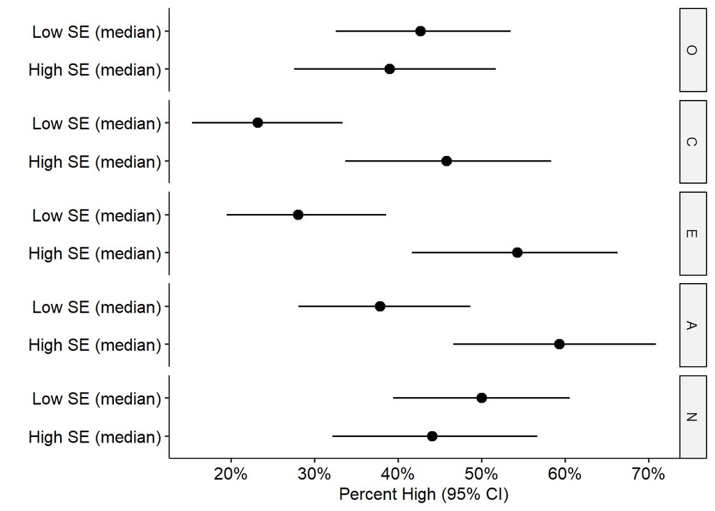

```r
p.prop2 <- ggplot(propdata2, aes(SelfesteemHigh, y = Percent, ymin = LL, ymax = UL)) +
  geom_pointrange() +
  scale_y_continuous(labels = percent) +
  scale_x_discrete(
    breaks = c("High SE", "Low SE"),
    labels = c("High SE (median)", "Low SE (median)")) +
  xlab("") + ylab("Percent High (95% CI)") +
  theme_pubr() +
  facet_grid(Personality ~ .) + #when we created propdata2 in the chunk above, we told it to make a factor called Personality with O,C,E,A,N levels
  coord_flip()

print(p.prop2)
```

# 11 All Continuous Variables

For all continuous variables, there are not many graphing options. A scatter plot is the main way two continuous variables are visualized. However, even with a scatter plot, we can add additional information to make it more useful. Our starting point is the scatter plots we went over earlier. To that we add a linear regression line to help show the overall association between the two variables. We also add a text annotation with the correlation coefficient and p-value, found from running the `cor.test()` function. We label it using `xlab()` and `ylab()`. The main plot is saved in an object, `p.ss`. Finally, we use the `ggMarginal()` function from the `ggExtra` package to add histograms of the univariate distributions to the margins. The final result captures extensive information about the individual variables (through the histograms and five number summaries in the axes) and about their association (through the scatter plot, regression line, and correlation coefficient).

```r
cor.test(~ SE + Stress, data = db)
```

```
    Pearson's product-moment correlation

data:  SE and Stress
t = -10, df = 140, p-value <2e-16
alternative hypothesis: true correlation is not equal to 0
95 percent confidence interval:
 -0.733 -0.539
sample estimates:
   cor
-0.646
```

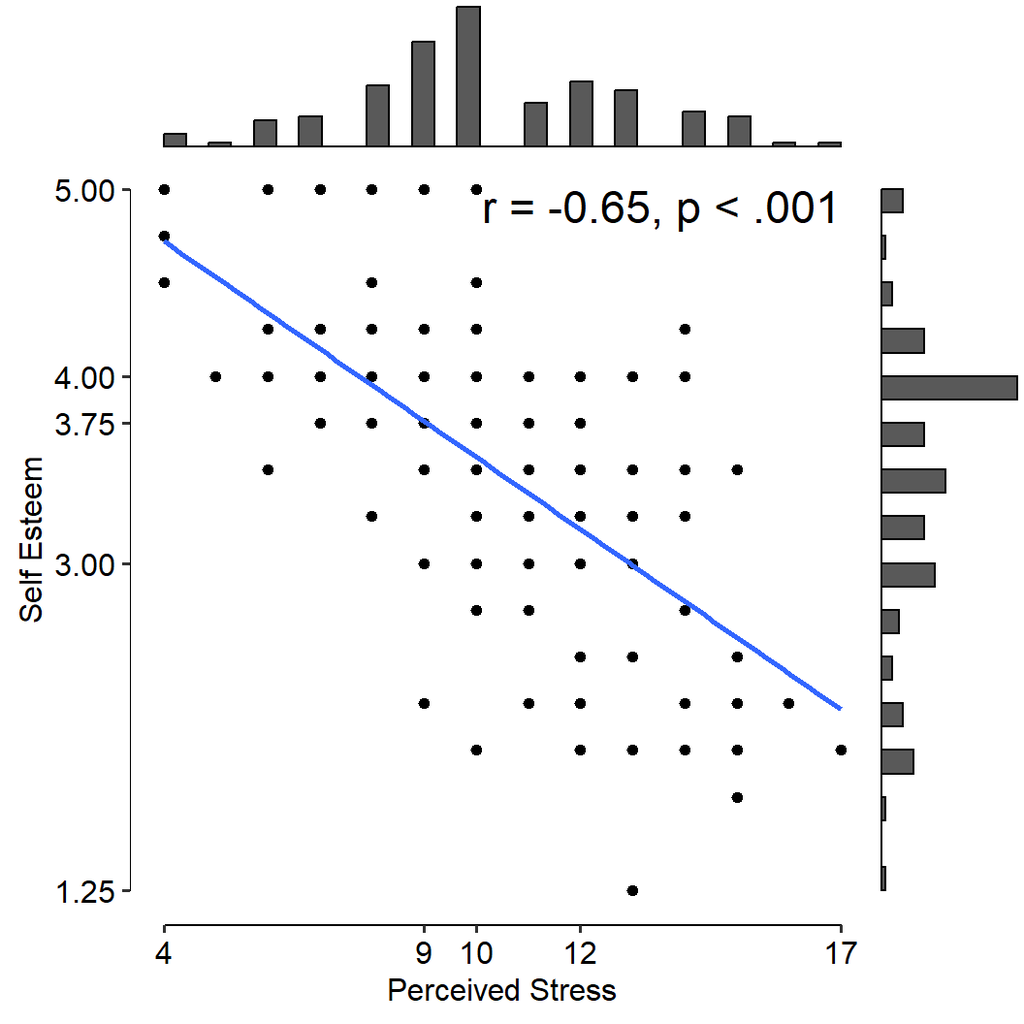

scatter plot with regression line and correlation

```r
p.ss <- ggplot(db, aes(Stress, SE)) +
  geom_point() +
  stat_smooth(method = "lm", se = FALSE, size = 1) +
  scale_x_continuous(breaks = as.numeric(quantile(db$Stress))) +
  scale_y_continuous(breaks = as.numeric(quantile(db$SE))) +
  theme_pubr() +
  theme(axis.line = element_blank()) +
  geom_rangeframe() +
  xlab("Perceived Stress") +
  ylab("Self Esteem") +
  annotate("text", x = max(db$Stress), y = max(db$SE),
           label = "r = -0.65, p < .001",
           size = 6, hjust = 1, vjust = 1)

## now add a histogram to the margins
ggMarginal(p.ss, type = "histogram")
```

**Note**

Because we did not store the results of Stress and selfesteem with the histograms added to the margins, we have the basic scatter plots in the figure, but we could have the histograms as well if desired by saving the result in p.ss.

Another feature that is helpful with figures is to arrange sets of related figures together. For example, in the following code we make a plot of Stress and neuroticism scores and save it in `p.sn`. Now we can make a panel of graphs with two columns using the `ggarrange()` function.

```r
cor.test(~ neuroticism + Stress, data = db)
```

```
    Pearson's product-moment correlation

data:  neuroticism and Stress
t = 7, df = 139, p-value = 7e-10
alternative hypothesis: true correlation is not equal to 0
95 percent confidence interval:
 0.354 0.607
sample estimates:
 cor
0.49
```

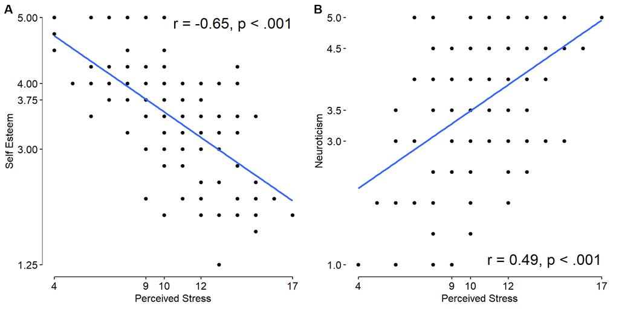

panel graph of two scatter plots

```r
# note I had to add na.rm argument to the quantile and min functions for neuroticism
p.sn <- ggplot(db, aes(Stress, neuroticism)) +
  geom_point() +
  stat_smooth(method = "lm", se = FALSE, size = 1) +
  scale_x_continuous(breaks = as.numeric(quantile(db$Stress))) +
  scale_y_continuous(breaks = as.numeric(quantile(db$neuroticism, na.rm = TRUE))) +
  theme_pubr() +
  theme(axis.line = element_blank()) +
  geom_rangeframe() +
  xlab("Perceived Stress") +
  ylab("Neuroticism") +
  annotate("text", x = max(db$Stress), y = min(db$neuroticism, na.rm = TRUE),
           label = "r = 0.49, p < .001",
           size = 6, hjust = 1, vjust = 0)

ggarrange(
  p.ss, p.sn,
  ncol = 2,
  labels = c("A", "B"))
```

# 12 Mixed Continuous and Categorical Variables

The most variety of graphs are possible with data that are a mix of continuous and categorical variables. As an example we will work with self esteem group, sex, and the five personality traits. We start by reshaping them long so that which personality measure is being examined becomes another categorical variable.

```r
dblong2 <- reshape(
  db[!is.na(SelfesteemHigh), .(ID, SelfesteemHigh, sex, openness, conscientiousness, extraversion, agreeableness, neuroticism)],
  varying = list(Score = c("openness", "conscientiousness", "extraversion", "agreeableness", "neuroticism")),
  v.names = "Score",
  timevar = "Personality",
  times = c("O", "C", "E", "A", "N"),
  idvar = "ID",
  direction = "long")
dblong2[, Personality := factor(Personality, levels = c("O", "C", "E", "A", "N"))]

head(dblong2)
```

```
      ID SelfesteemHigh    sex Personality Score
   <num>         <fctr> <fctr>      <fctr> <num>
1:    NA         Low SE female           O   4.0
2:    10         Low SE female           O   3.5
3:    11         Low SE   male           O   3.0
4:    12        High SE female           O   4.0
5:    13         Low SE female           O   3.0
6:    14         Low SE female           O   2.0
```

We can make a simple plot with the means and 95% confidence intervals using the following code.

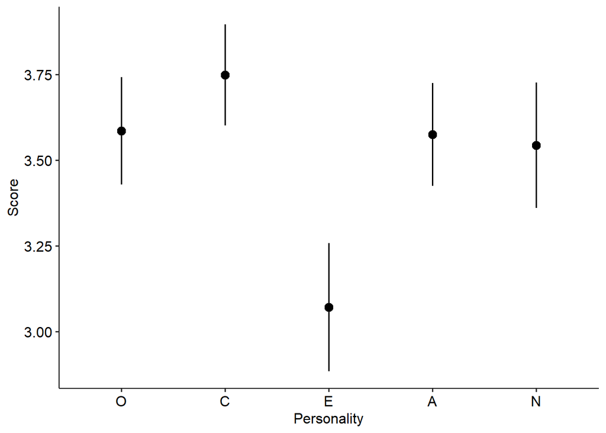

```r
p.mean1 <- ggplot(dblong2, aes(Personality, Score)) +
  stat_summary(fun.data = mean_cl_normal) +
  theme_pubr()

print(p.mean1)
```

There are lots of additions we could consider to this simple figure. The labels are short, but not the most informative. We could re-label the axis.

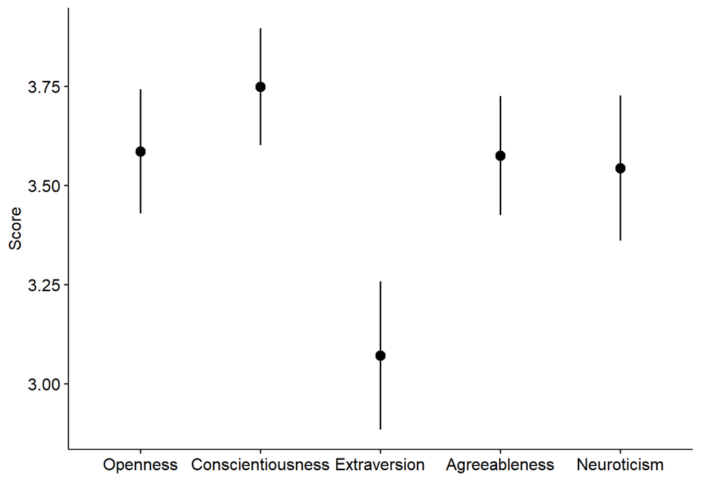

```r
p.mean2 <- p.mean1 +
  scale_x_discrete("",
    breaks = c("O", "C", "E", "A", "N"),
    labels = c("Openness", "Conscientiousness", "Extraversion", "Agreeableness", "Neuroticism"))

print(p.mean2)
```

Long labels are messy in smaller spaces. We could rotate the labels to make space or rotate the graph.

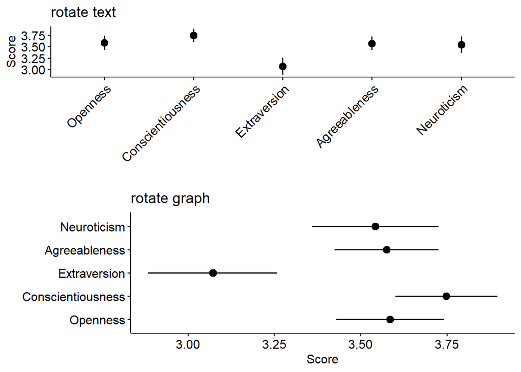

```r
ggarrange(
  p.mean2 +
    theme(axis.text.x = element_text(angle = 45, hjust = 1, vjust = 1)) +
    ggtitle("rotate text"),
  p.mean2 +
    coord_flip() +
    ggtitle("rotate graph"),
  ncol = 1)
```

Either rotating the labels or the graph made it easier to have long labels and clearly read them, in this case especially rotating the graph so the longest words can be read in their usual left to right orientation.

With smaller datasets, we could show raw data as well as the means. Although relatively easy to add, the result is disastrous. Even though this is not a huge dataset, there is enough data and because there are not many different possible values for each personality measure, the dotplot is very difficult to read. Lastly, because of the black dots and the means being shown as black dots, it becomes impossible to well see the means.

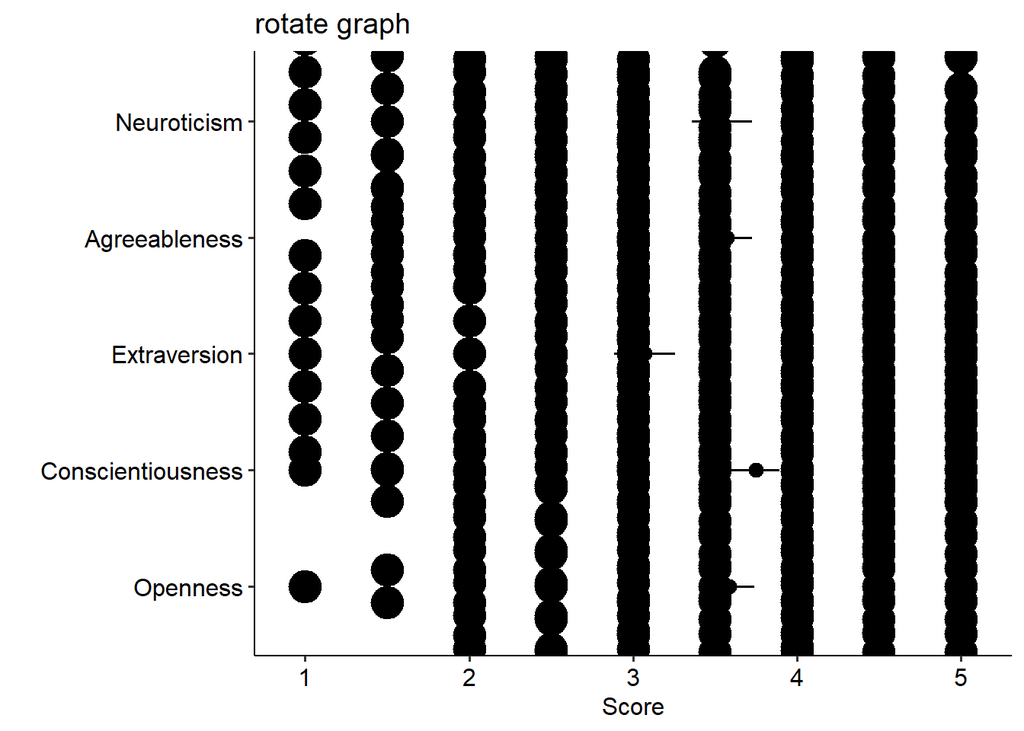

```r
p.mean2 +
  geom_dotplot(binaxis = "y", stackdir = "center", binwidth = .2) +
    coord_flip() +
    ggtitle("rotate graph")
```

By shrinking the size of the dots further (using `binwidth = .1`), adding some transparency using the `alpha = .2` argument (valid numbers are 0 completely transparent to 1 completely opaque) and adding some random noise on the scores using `jitter()` we can see the raw data and means better. It is not quite the actual raw data, because we have added some noise, but it could still help to show the general spread of data.

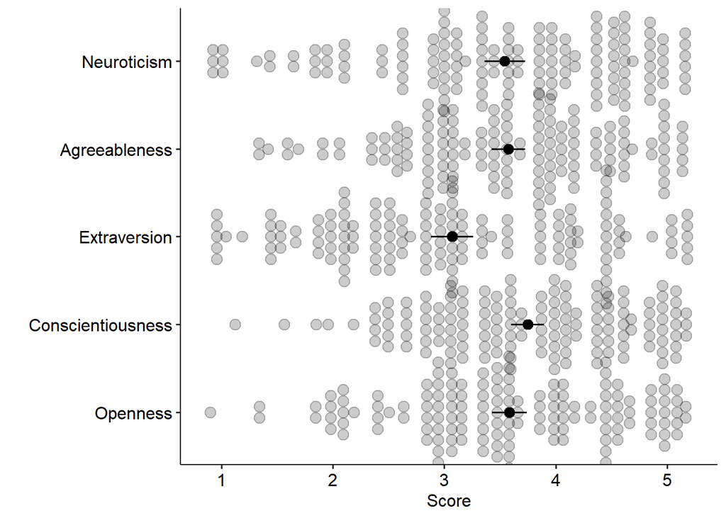

```r
p.mean2 +
  geom_dotplot(aes(y = jitter(Score, 2)), binaxis = "y",
               alpha = .2,
               stackdir = "center", binwidth = .1) +
    coord_flip()
```

For larger datasets or if the dotplot with noise is not as useful anymore because it’s not true raw data, a more summarized version of the distribution can be shown with a violin plot, which is basically a density plot that is mirrored. Thicker regions have more points, narrow regions have fewer data points. We can also see the range/spread of each variable and still have our mean and confidence interval summaries shown clearly.

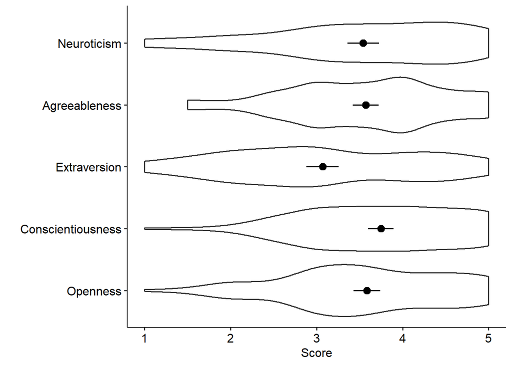

```r
p.mean3 <- p.mean2 +
  geom_violin(fill = NA) +
  coord_flip()

print(p.mean3)
```

Another aspect we could improve: there is no necessary ordering of personality measures. Ordering them such as from highest to lowest mean can be used to help us read the plot more easily.

We do this by changing the levels of the factor in the dataset. First, we calculate the mean score by personality, then we have data table order the resulting means from highest to lowest (these are things we saw in the working with data topic). Finally, we use `factor()` on personality and specify the levels in this same order.

```r
dblong2[, .(M = mean(Score, na.rm = TRUE)), by = Personality][
  order(-M)]
```

```
   Personality     M
        <fctr> <num>
1:           C  3.75
2:           O  3.59
3:           A  3.57
4:           N  3.54
5:           E  3.07
```

```r
dblong2[, Personality := factor(Personality,
                                levels = c("C", "O", "A", "N", "E"))]
```

Now we can simply remake our graph (note that this only works when using data.table for data management, if using data frames etc. you would want to copy and paste all your graph code again).

By having ordered the variables by their means, it helps us rapidly interpret which one has the lowest score (extraversion) and which the highest average score (conscientiousness). It is a small step but one that aids rapid processing of the figure and the data therein.

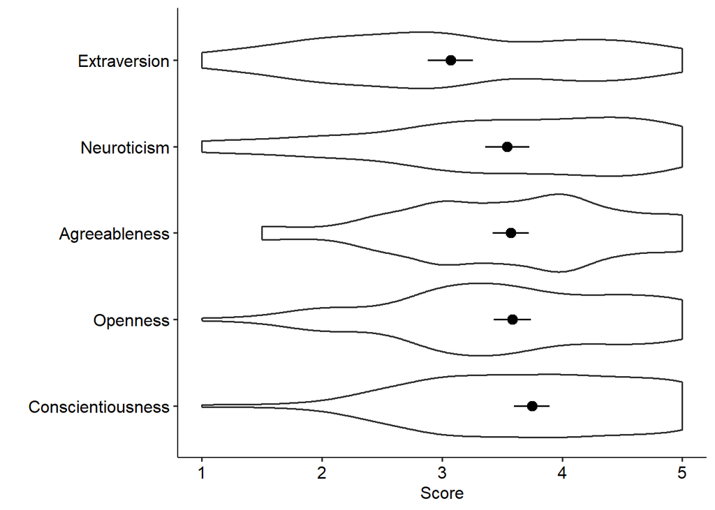

```r
print(p.mean3)
```

It is easy to add additional categorical variables into a figure. For example, we can colour by self esteem group.

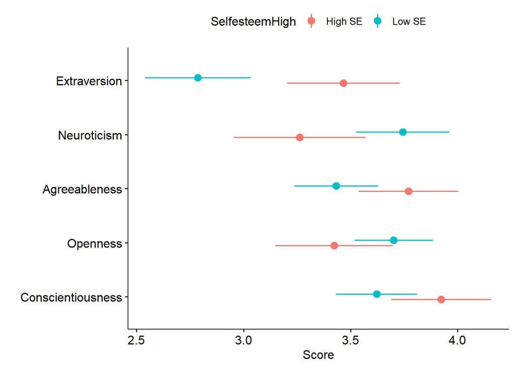

```r
ggplot(dblong2, aes(Personality, Score, colour = SelfesteemHigh)) +
  stat_summary(fun.data = mean_cl_normal, position = position_dodge(.2)) +
  scale_x_discrete("",
    breaks = c("O", "C", "E", "A", "N"),
    labels = c("Openness", "Conscientiousness", "Extraversion", "Agreeableness", "Neuroticism")) +
  theme_pubr() +
  coord_flip()
```

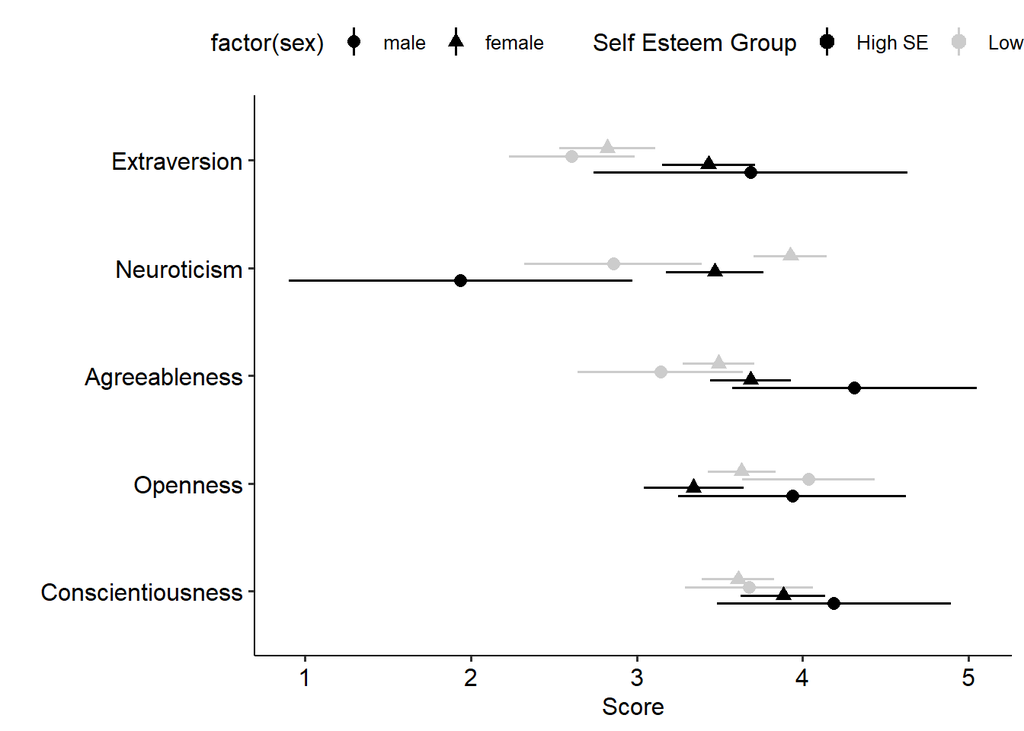

```r
ggplot(dblong2, aes(Personality, Score, colour = SelfesteemHigh, shape = factor(sex))) +
  stat_summary(fun.data = mean_cl_normal, position = position_dodge(.3)) +
  scale_x_discrete("",
    breaks = c("O", "C", "E", "A", "N"),
    labels = c("Openness", "Conscientiousness", "Extraversion", "Agreeableness", "Neuroticism")) +
  theme_pubr() +
  coord_flip() +
  scale_colour_manual(
    "Self Esteem Group",
    values = c("High SE" = "black", "Low SE" = "grey80"))
```

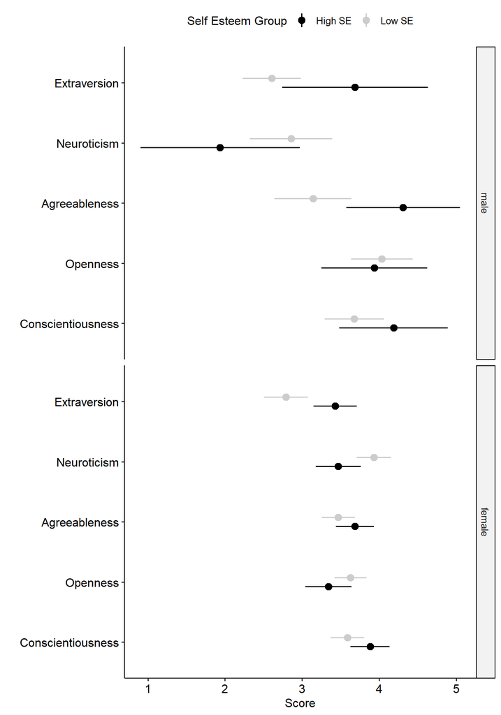

```r
# note the use of na.omit at the beginning of ggplot. This is because there is NA data in 'sex'
# and we don't want a separate facet for sex = NA
ggplot(na.omit(dblong2), aes(Personality, Score, colour = SelfesteemHigh)) +
  stat_summary(fun.data = mean_cl_normal, position = position_dodge(.3)) +
  scale_x_discrete("",
    breaks = c("O", "C", "E", "A", "N"),
    labels = c("Openness", "Conscientiousness", "Extraversion", "Agreeableness", "Neuroticism")) +
  theme_pubr() +
  coord_flip() +
  facet_grid(sex ~ .) +
  scale_colour_manual(
    "Self Esteem Group",
    values = c("High SE" = "black", "Low SE" = "grey80"))
```

If we wanted to show the raw data, we could facet on both self esteem and sex and add our dotplots back in.

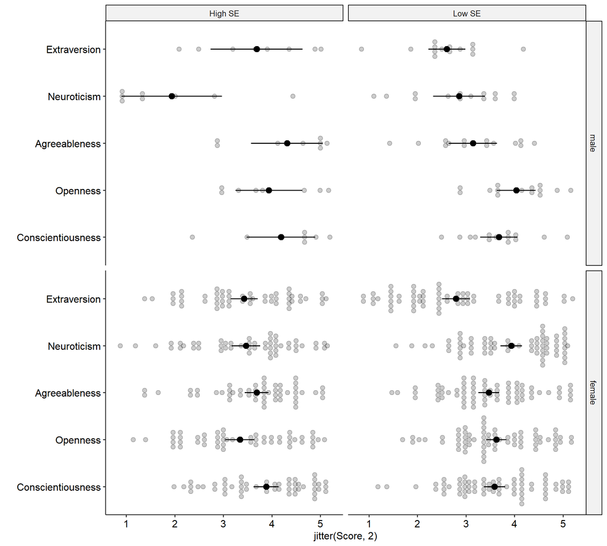

```r
ggplot(na.omit(dblong2), aes(Personality, Score)) +
  geom_dotplot(aes(y = jitter(Score, 2)), binaxis = "y",
               alpha = .2,
               stackdir = "center", binwidth = .1) +
  stat_summary(fun.data = mean_cl_normal, position = position_dodge(.2)) +
  scale_x_discrete("",
    breaks = c("O", "C", "E", "A", "N"),
    labels = c("Openness", "Conscientiousness", "Extraversion", "Agreeableness", "Neuroticism")) +
  theme_pubr() +
  coord_flip() +
  facet_grid(sex ~ SelfesteemHigh)
```